# housing

We will explore a dataset of Melbourne house price data (available via Kaggle: https://www.kaggle.com/anthonypino/melbourne-housing-market) with a view to modelling the relationship between variables using a Linear Regression model.

I have removed several fields from the dataset to make the analysis slightly simpler, and more generalisable.

```python
import matplotlib.pyplot as plt
import numpy as np
import pandas as pd
import seaborn as sns
from sklearn.linear_model import LinearRegression
from sklearn.model_selection import train_test_split
```

```python
sns.set()
%matplotlib inline
plt.rcParams['figure.dpi'] = 150
plt.rcParams['figure.figsize'] = (8,5)
```

With the usual libraries imported and plot parameters set, we can load the dataset.

We then drop **all** rows containing any NA values. This is to make our demonstration easier and cleaner. This will of course reduce the size of the dataset and may bias it (if the missing values disproportionately represented, for example, cheaper properties) so in a 'real' analysis this is not a decision to be taken lightly.

```python
housing = pd.read_csv("Melbourne_housing_FULL.csv")
housing.dropna(inplace=True)
```

Let's have a look at some basic info about the data, including showing which columns I've kept from the original dataset.

```python
housing.describe()
```

|  | Rooms | Price | Distance | Bedroom2 | Bathroom | Car | Landsize | BuildingArea | YearBuilt |
| --- | --- | --- | --- | --- | --- | --- | --- | --- | --- |
| count | 8895.00000 | 8.895000e+03 | 8895.000000 | 8895.000000 | 8895.000000 | 8895.000000 | 8895.000000 | 8895.000000 | 8895.000000 |
| mean | 3.09882 | 1.092524e+06 | 11.202136 | 3.078134 | 1.646655 | 1.692636 | 523.395166 | 149.295708 | 1965.777403 |
| std | 0.96359 | 6.792066e+05 | 6.815113 | 0.966070 | 0.721388 | 0.975393 | 1060.940841 | 87.898565 | 37.055054 |
| min | 1.00000 | 1.310000e+05 | 0.000000 | 0.000000 | 1.000000 | 0.000000 | 0.000000 | 0.000000 | 1196.000000 |
| 25% | 2.00000 | 6.405000e+05 | 6.400000 | 2.000000 | 1.000000 | 1.000000 | 212.000000 | 100.000000 | 1945.000000 |
| 50% | 3.00000 | 9.000000e+05 | 10.200000 | 3.000000 | 2.000000 | 2.000000 | 478.000000 | 132.000000 | 1970.000000 |
| 75% | 4.00000 | 1.345000e+06 | 13.900000 | 4.000000 | 2.000000 | 2.000000 | 652.000000 | 180.000000 | 2000.000000 |
| max | 12.00000 | 9.000000e+06 | 47.400000 | 12.000000 | 9.000000 | 10.000000 | 42800.000000 | 3112.000000 | 2019.000000 |

The min of the yearbuilt column stands out here as a probable error, so we'll drop that record:

```python
housing = housing[housing.YearBuilt != 1196.0]
housing.describe()
```

|  | Rooms | Price | Distance | Bedroom2 | Bathroom | Car | Landsize | BuildingArea | YearBuilt |
| --- | --- | --- | --- | --- | --- | --- | --- | --- | --- |
| count | 8894.000000 | 8.894000e+03 | 8894.000000 | 8894.000000 | 8894.000000 | 8894.000000 | 8894.000000 | 8894.000000 | 8894.000000 |
| mean | 3.098831 | 1.092512e+06 | 11.201799 | 3.078143 | 1.646728 | 1.692377 | 523.363279 | 149.299339 | 1965.863953 |
| std | 0.963644 | 6.792438e+05 | 6.815422 | 0.966124 | 0.721396 | 0.975140 | 1060.996227 | 87.902840 | 36.146813 |
| min | 1.000000 | 1.310000e+05 | 0.000000 | 0.000000 | 1.000000 | 0.000000 | 0.000000 | 0.000000 | 1830.000000 |
| 25% | 2.000000 | 6.402500e+05 | 6.400000 | 2.000000 | 1.000000 | 1.000000 | 212.000000 | 100.000000 | 1945.000000 |
| 50% | 3.000000 | 9.000000e+05 | 10.200000 | 3.000000 | 2.000000 | 2.000000 | 477.500000 | 132.000000 | 1970.000000 |
| 75% | 4.000000 | 1.345000e+06 | 13.900000 | 4.000000 | 2.000000 | 2.000000 | 652.000000 | 180.000000 | 2000.000000 |
| max | 12.000000 | 9.000000e+06 | 47.400000 | 12.000000 | 9.000000 | 10.000000 | 42800.000000 | 3112.000000 | 2019.000000 |

And now for that staple of exploratory data analysis, the scatterplot matrix (or pair plot, correlogram and probably other names too).

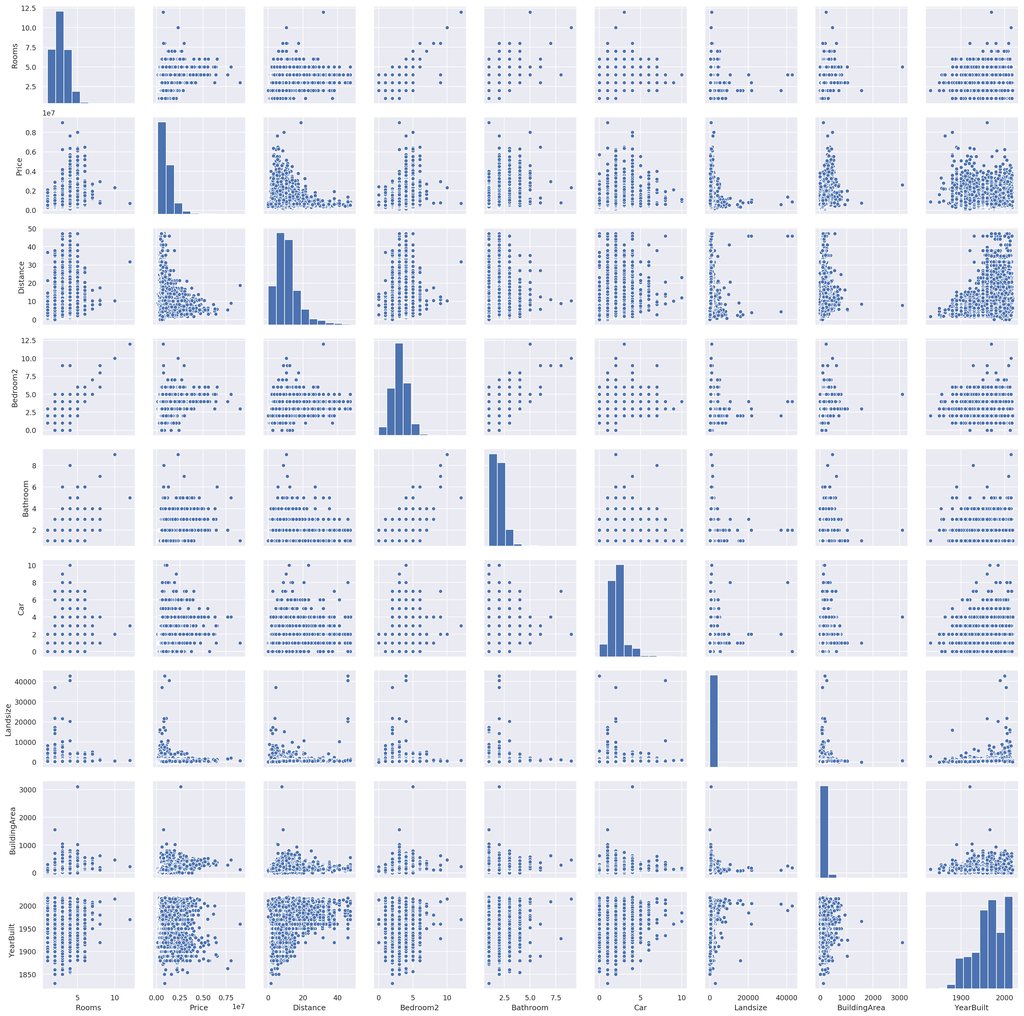

```python
sns.pairplot(housing)
plt.show()
```

I'd say the strongest correlation visible there is rooms:bedrooms. Hardly a surprise. But that's no bad thing: it indicates a well distributed dataset and the absence of any one dominant variable - all the better for demonstrating a linear regression.

The corr() function tells us much the same thing without the visualisation, if that's more your thing:

```python
housing.corr()
```

|  | Rooms | Price | Distance | Bedroom2 | Bathroom | Car | Landsize | BuildingArea | YearBuilt |
| --- | --- | --- | --- | --- | --- | --- | --- | --- | --- |
| Rooms | 1.000000 | 0.474858 | 0.276989 | 0.964482 | 0.623980 | 0.401405 | 0.101065 | 0.606833 | 0.007191 |
| Price | 0.474858 | 1.000000 | -0.231378 | 0.460660 | 0.463190 | 0.209152 | 0.058419 | 0.507205 | -0.321345 |
| Distance | 0.276989 | -0.231378 | 1.000000 | 0.283862 | 0.122446 | 0.259435 | 0.138286 | 0.135722 | 0.322711 |
| Bedroom2 | 0.964482 | 0.460660 | 0.283862 | 1.000000 | 0.626411 | 0.405554 | 0.100940 | 0.595396 | 0.016858 |
| Bathroom | 0.623980 | 0.463190 | 0.122446 | 0.626411 | 1.000000 | 0.311458 | 0.075764 | 0.553735 | 0.196095 |
| Car | 0.401405 | 0.209152 | 0.259435 | 0.405554 | 0.311458 | 1.000000 | 0.123288 | 0.317631 | 0.148716 |
| Landsize | 0.101065 | 0.058419 | 0.138286 | 0.100940 | 0.075764 | 0.123288 | 1.000000 | 0.083204 | 0.038817 |
| BuildingArea | 0.606833 | 0.507205 | 0.135722 | 0.595396 | 0.553735 | 0.317631 | 0.083204 | 1.000000 | 0.060625 |
| YearBuilt | 0.007191 | -0.321345 | 0.322711 | 0.016858 | 0.196095 | 0.148716 | 0.038817 | 0.060625 | 1.000000 |

Price is going to be our dependent variable, so let's have a look how it's distributed in the source data:

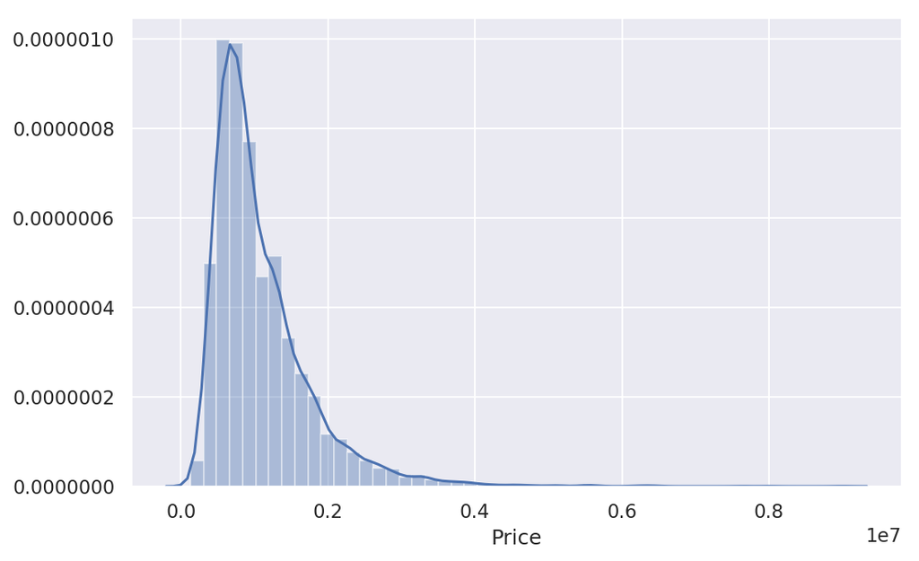

```python
sns.distplot(housing.Price)
plt.show()
```

The long right tail suggests to me that a logarithmic visualisation might be more appropriate:

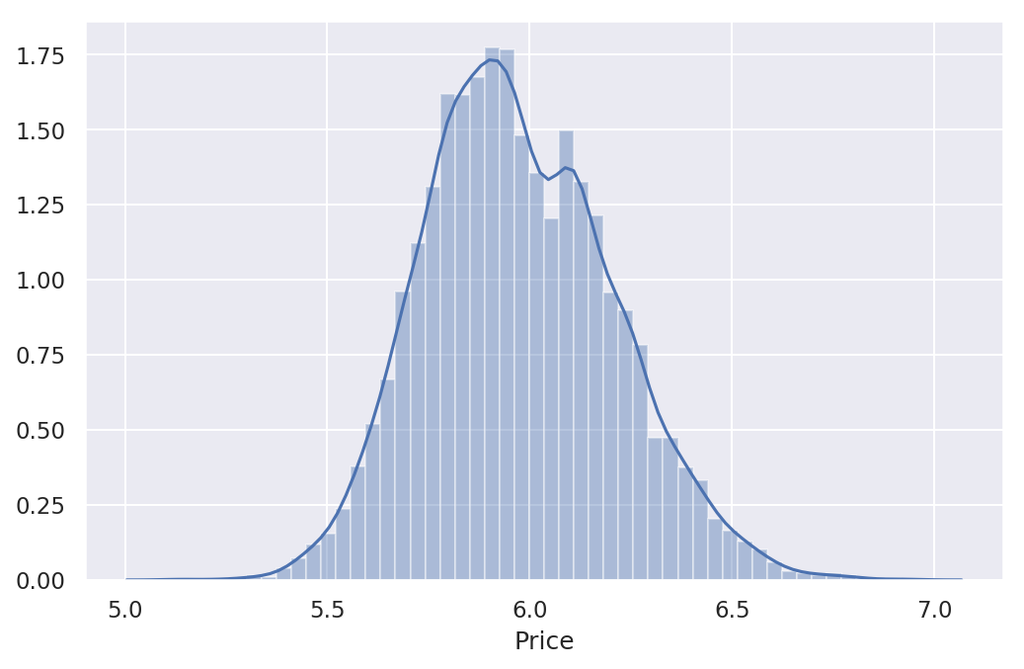

```python
sns.distplot(np.log10(housing.Price))
plt.show()
```

That's much closer to a normal distribution. Note the secondary peak around 6.1. This could be a statistical fluke due to insufficient data, or could indicate something psychological; once the approximate value of a house reaches a particular point (1 million dollars in this case), prices are more likely to tend towards 'round' figures. I'm sure a behavioural economist would have more to say about this.

Moving towards prediction, we set up our independent ($X$) variables, and our dependent ($y$)

```python
X = housing[["Rooms", "Distance", "Bedroom2", "Bathroom", "Car", "Landsize", "BuildingArea", "YearBuilt"]]
y = housing["Price"]
```

And use sklearn to split our data into a training set (70%) and test (30%):

(Random state is set for reproducibility on this notebook, but would be left out in a 'real' situation.)

```python
X_train, X_test, y_train, y_test = train_test_split(X, y, test_size=0.3, random_state=23)
```

And train the model:

(Though it's hidden from us, scikit-learn uses a common Ordinary Least Squares method)

```python
lm = LinearRegression()
lm.fit(X_train, y_train)
```

```
LinearRegression(copy_X=True, fit_intercept=True, n_jobs=None,
         normalize=False)
```

In case you're interested, we'll view the coefficients that scikit-learn has identified:

```python
lm.coef_
```

```
array([ 1.23206690e+05, -2.76300155e+04, -7.45640340e+03,  2.27853160e+05,
        5.15010959e+04,  2.14063695e+01,  2.68959116e+03, -5.79177247e+03])
```

From those coefficients we can see which variables were given the greatest weight by the model:

```python
cols = ["Rooms", "Distance", "Bedroom2", "Bathroom", "Car", "Landsize", "BuildingArea", "YearBuilt"]
i=0
for x in lm.coef_:
    print(str(int(x)).rjust(6), ":",cols[i])
    i += 1
```

```
123206 : Rooms
-27630 : Distance
 -7456 : Bedroom2
227853 : Bathroom
 51501 : Car
    21 : Landsize
  2689 : BuildingArea
 -5791 : YearBuilt
```

We can see that distance (from a point in the centre of Melbourne) is inversely correlated with price, as is the year built. The fact that the Bedroom2 column is inversely correlated with price is a puzzle. Comments from the dataset creator (https://www.kaggle.com/anthonypino/melbourne-housing-market/discussion/32987) state that this column was obtained separately to the rest of the data. Given this, I'm going to assume there is a problem with it and exclude it from the model.

So, going back a few steps:

```python
X = housing[["Rooms", "Distance", "Bathroom", "Car", "Landsize", "BuildingArea", "YearBuilt"]]
y = housing["Price"]
```

```python
X_train, X_test, y_train, y_test = train_test_split(X, y, test_size=0.3, random_state=23)
```

```python
lm = LinearRegression()
lm.fit(X_train, y_train)
```

```
LinearRegression(copy_X=True, fit_intercept=True, n_jobs=None,
         normalize=False)
```

Now we'll use the model to predict on the test data:

```python
predictions = lm.predict(X_test)
```

Finally we will visualise our prediction accuracy:

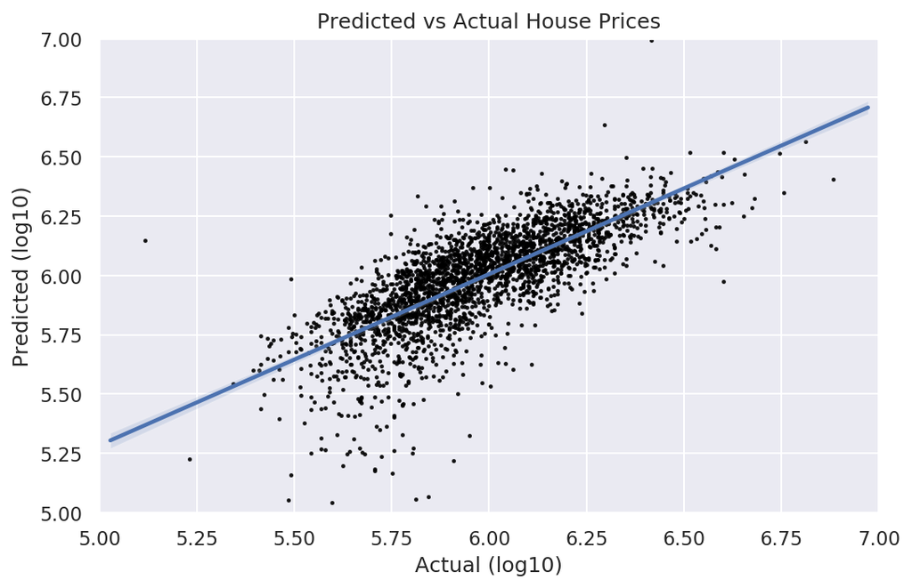

```python
sns.regplot(x=np.log10(y_test), y=np.log10(predictions), scatter_kws={"color":"black", "s":2}, fit_reg=True)
plt.ylim(5,7)
plt.xlim(5,7)
plt.title("Predicted vs Actual House Prices")
plt.xlabel("Actual (log10)")
plt.ylabel("Predicted (log10)")
plt.show()
```

I used log10 scales again to ensure a reasonably distributed chart. On a normal scale there would be a dense cluster of points in the bottom left and little elsewhere.

We can see our simple linear regression is reasonably accurate. It appears to overvalue less valuable properties and undervalue more valuable ones (suggesting too great an intercept and too small a gradient) but it doesn't perform badly overall.